# Week 1: Introduction

Tristan Muno

October 7, 2026

## Today

1. Introduction
   - About me
   - About you
2. Statistics in a nutshell
3. Applied example of Bayesian inference
4. Course logistics
5. Recap: the normal distribution

## Before we start

Please fill this in now. It takes about five minutes.

forms.gle/kkvtRQXW5UJMoWq1A

[figure not shown]

# Introduction

## About me

## About you

- What name would you prefer us to call you?
- What natural languages do you speak (or are currently learning)?
- How do you like to spend time outside of university?
- In what ways did you learn or come across statistics before?

# Statistics in a nutshell

## What is statistics?

In a nutshell, you may think of statistics as counting.

- **Counting values.** How many people are 20 years old? How many flips were heads? How many birds were observed?
- **Counting how much you counted.** How many observations do we have?
- **Official counting.** Births, deaths, unemployment, crime.
- **Counting the ways things could have happened.** How much could our count have varied by chance? How many heads would a fair coin give us?

> Statistics can be thought of as counting, and as reasoning about counts and their possible variation.

## Why statistics?

Fundamentally, we want to learn about the world using observations. Put differently, we want to learn from data.

- **Estimand:** the quantity we want to learn about (what we want).
- **Estimator:** the procedure by which we learn about it (our method).
- **Estimate:** the result that procedure gives us (what we get).

**Inference** is using *known* information to *infer* something *unknown*.

- Collecting measurements to infer the association between two variables.
- Collecting a random sample to infer something about a larger population.
- Running randomised experiments to infer a potential outcome.

## Fundamental issue in statistics

- We want to separate **noise** from **signal**.
- That is, how certain can we be in our estimate?
- Put differently: how certain can we be that an estimated association between two variables is a *real world* association, rather than the result of *random* variation during our measurement or data collection?
- This is the fundamental challenge and task of quantitative methods in all science.

# Applied example of Bayesian inference

**Note**

**You are not expected to understand this yet.** We will learn and practise every one of these steps over the course of the semester. Watch the shape of the argument rather than the code.

## A question

> Do students become more confident in statistics as they progress through their studies?

You just filled out the survey, which asked, among other things, for your current semester and your confidence in reading statistical results.

## Step 1: Clarify the estimand

What precisely do we want to learn about?

> The association between semester of study and reported confidence on a 1 to 10 scale.

**Warning**

**An association is not a causal effect.** Nobody was assigned a semester, so we are comparing different people rather than following one person through their degree. Causal identification is a separate course.

## Step 2: Data summary

- **Semester** as an integer.
- **Confidence** as a number from 1 (not at all confident) to 10 (very confident).

**View source**

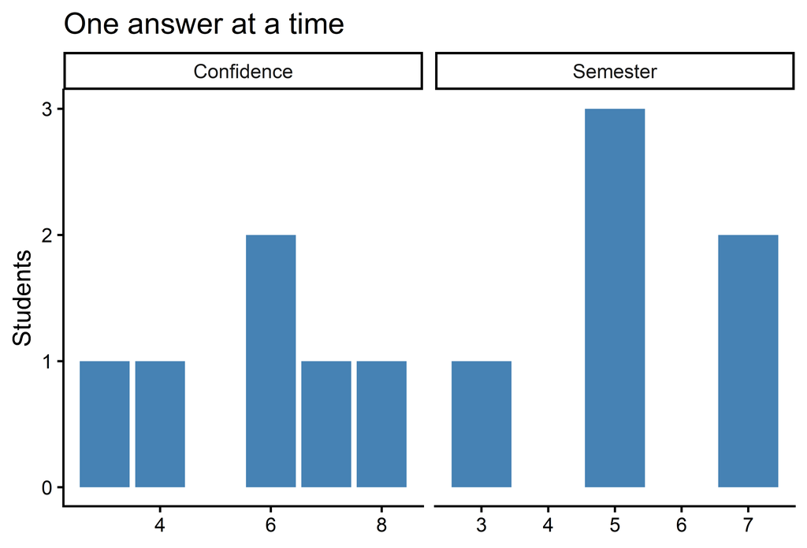

```r
distributions <- model_df |>
  pivot_longer(
    c(semester, conf_stats),
    names_to = "variable",
    values_to = "value"
  ) |>
  mutate(
    variable = case_match(
      variable,
      "semester" ~ "Semester",
      "conf_stats" ~ "Confidence"
    )
  )

ggplot(distributions, aes(x = value)) +
  geom_bar(fill = col_1) +
  facet_wrap(~variable, scales = "free_x") +
  theme_classic() +
  labs(x = NULL, y = "Students", title = "One answer at a time")
```

**View source**

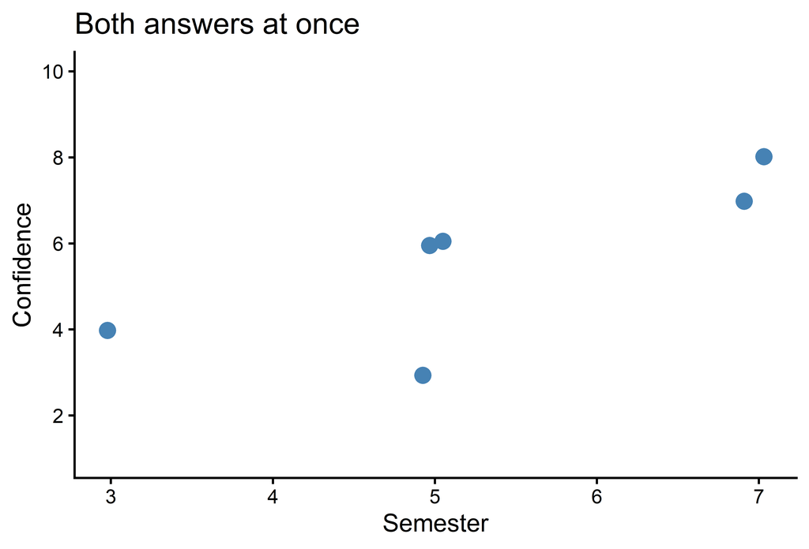

Figure 2: Self-rated confidence against current semester, one point per respondent. Points are nudged slightly so that two people giving the same pair of answers stay visible.

```r
set.seed(2026)
ggplot(model_df, aes(x = semester, y = conf_stats)) +
  geom_jitter(width = 0.1, height = 0.1, colour = col_1, size = 3) +
  scale_y_continuous(breaks = seq(2, 10, by = 2), limits = c(1, 10)) +
  theme_classic() +
  labs(x = "Semester", y = "Confidence", title = "Both answers at once")
```

The outcome is (nearly) continuous, which is what justifies a linear model.

## Step 3: Formal model

Given our approximately continuous outcome, and for the sake of simplicity, we use a bivariate linear model.

**Outcome family**

$$\text{Confidence}_i \sim \mathcal{N}(\mu_i, \sigma)
\tag{1}$$

**How to read the outcome family**

**Note**

**Equation 1 in words.** We assume the outcome, the reported confidence of student $i$, to be normally distributed with mean $\mu_i$ and standard deviation $\sigma$.

**Linear predictor**

$$\mu_i = \alpha + \beta \times \text{Semester}_i
\tag{2}$$

**How to read the linear predictor**

**Note**

**Equation 2 in words.** We model the mean confidence score as a function of the reported semester. $\alpha$ is the baseline level of reported confidence for a hypothetical semester 0 student, the intercept. $\beta$ is the average change in reported confidence per unit change in semester, and it is therefore our estimand, the slope. Everything the semester does not account for is the residual spread, which is the $\sigma$ of Equation 1.

## Step 3: The posterior

$$P(\alpha, \beta, \sigma \mid \text{Data}) \propto \mathcal{L}(\alpha, \beta, \sigma \mid \text{Data}) \times P(\alpha, \beta, \sigma)
\tag{3}$$

**How to read the posterior**

**Note**

**Equation 3 in words.** The probability of our model parameters ($\alpha$, $\beta$, $\sigma$) *given* the data we collected, here the confidence and semester answers, is proportional to the likelihood, a function assessing the plausibility of different parameter values given our data, multiplied by the prior distributions of those parameters.

The posterior is a full probability distribution, not a single number.

## Step 3: The priors

A prior is a probability distribution over a parameter before seeing the data. I chose:

$$\alpha \sim \mathcal{N}(5, 2), \qquad \beta \sim \mathcal{N}(0, 2), \qquad \sigma \sim \text{Exponential}(1)
\tag{4}$$

**How to read the prior on the intercept**

**Note**

**The prior on $\alpha$ in words.** Before evaluating the observed data, the expected intercept sits in the middle of the outcome scale (5), and with 95 percent probability it is 5 plus or minus about 4. As in Equation 1, the pair in $\mathcal{N}(5, 2)$ is a mean and a standard deviation, which is also what `brms` expects.

**How to read the prior on the slope**

**Note**

**The prior on $\beta$ in words.** My prior expectation is that there is *no association*, hence a mean of 0, but with 95 percent probability it lies between -4 and +4, which would be very large effects on a 10 point scale.

**How to read the prior on the residual spread**

**Note**

**The prior on $\sigma$ in words.** Before knowing anything from the data I know the spread must be positive, so a normal distribution will not do. Small spreads are a priori more plausible than large ones.

## Step 3: The priors, drawn

**View source**

```r
priors_drawn <- bind_rows(
  tibble(
    parameter = "alpha: the intercept",
    value = seq(-3, 13, length.out = 200),
    density = dnorm(value, mean = 5, sd = 2)
  ),
  tibble(
    parameter = "beta: the slope",
    value = seq(-8, 8, length.out = 200),
    density = dnorm(value, mean = 0, sd = 2)
  ),
  tibble(
    parameter = "sigma: the spread",
    value = seq(0, 8, length.out = 200),
    density = dexp(value, rate = 1)
  )
)

ggplot(priors_drawn, aes(x = value, y = density)) +
  geom_line(colour = col_3, linewidth = 1) +
  facet_wrap(~parameter, scales = "free") +
  theme_classic() +
  labs(
    x = "Value",
    y = "Density",
    title = "What I believe before seeing any answer"
  )
```

[figure not shown]

Figure 3: The three priors as pictures. Each curve says how plausible I find each value of that parameter before seeing a single answer, which is why the slope curve is centred on zero and the spread curve never reaches below it.

## Step 4: Prior predictive check

What data would our prior beliefs produce?

**View source**

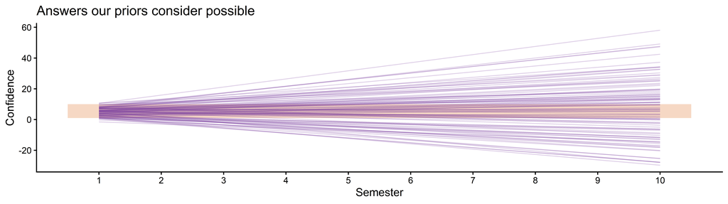

Figure 4: One hundred regression lines simulated from the priors alone, before any real answer was used. The shaded band is the 1 to 10 scale the survey actually offers, so every line leaving the band is a world our priors think possible and no student could ever report.

```r
set.seed(2026)
n_lines <- 100

# One draw from each prior is one possible world. Each world implies a whole line: the average
# answer it expects at every semester.
prior_lines <- tibble(
  draw = 1:n_lines,
  alpha = rnorm(n_lines, mean = 5, sd = 2),
  beta = rnorm(n_lines, mean = 0, sd = 2)
) |>
  expand_grid(semester = 1:10) |>
  mutate(confidence = alpha + beta * semester)

ggplot(prior_lines, aes(x = semester, y = confidence)) +
  annotate(
    "rect",
    xmin = 0.5,
    xmax = 10.5,
    ymin = 1,
    ymax = 10,
    fill = col_2,
    alpha = 0.3
  ) +
  geom_line(aes(group = draw), colour = col_3, alpha = 0.25, linewidth = 0.4) +
  scale_x_continuous(breaks = 1:10) +
  theme_classic() +
  labs(
    x = "Semester",
    y = "Confidence",
    title = "Answers our priors consider possible"
  )
```

## Step 5: Fit the model

**View source**

```r
model_priors <- c(
  prior(normal(5, 2), class = "b", coef = "Intercept"),
  prior(normal(0, 2), class = "b", coef = "semester"),
  prior(exponential(1), class = "sigma")
)

fit <- brm(
  conf_stats ~ 0 + Intercept + semester,
  data = model_df,
  family = gaussian(),
  prior = model_priors,
  chains = 4,
  iter = 2000,
  seed = 2026,
  refresh = 0,
  file = here("website", "slides", "data", "week01-fit"),
  file_refit = "on_change"
)
```

We will learn in week 7 what is going on here in detail.

In short: we update our prior distributions of the parameters by conditioning on the observed data. Computationally we simulate many different possible lines and rank them by their relative plausibility, and what comes back is a distribution of plausible regression lines.

## Step 6a: MCMC diagnostics

**View source**

```r
mcmc_plot(fit, type = "trace") +
  scale_colour_manual(values = chain_cols) +
  theme_classic()
```

[figure not shown]

Figure 5: Trace plots for the three parameters. Four searches started in different places and ended up wandering around the same region, which is what a working computation looks like. A line drifting off on its own would be the warning sign.

We are assessing the simulation algorithm here, and we will learn how in week 7.

## Step 6b: Posterior predictive check

**View source**

```r
set.seed(2026)
pp_check(fit, ndraws = 50) +
  theme_classic() +
  labs(
    x = "Confidence",
    title = "Observed answers against what the model predicts"
  )
```

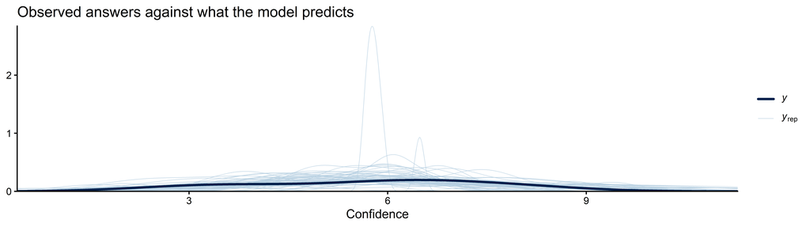

Figure 6: Posterior predictive check. The dark line is the confidence we actually observed, the pale lines are datasets the fitted model generates. Where they disagree is where the model is wrong about the world.

- How well do the estimated parameters, remember that these are distributions, combined with the predictor, replicate our outcome?
- Intuition: a model fits a dataset well if it can recover the outcomes well.

## Step 7: Interpretation

Each additional semester is associated with a change of **0.47** scale points of confidence, with a 90 percent credible interval from **-0.12** to **1**. The posterior puts **91 percent** of its mass above zero.

**View source**

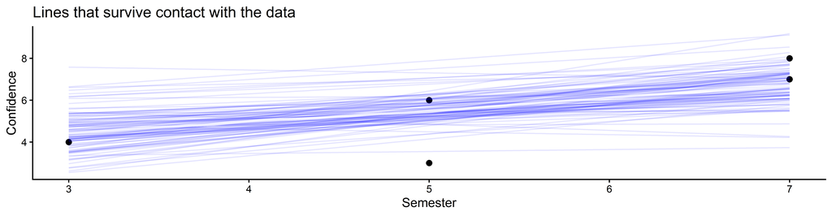

Figure 7: One hundred regression lines drawn from the posterior, with the observed answers on top. The spread of the lines is the honest summary of how far this data settles the question.

```r
line_cloud <- conditional_effects(fit, spaghetti = TRUE, ndraws = 100)

plot(line_cloud, points = TRUE, plot = FALSE)[[1]] +
  theme_classic() +
  labs(
    x = "Semester",
    y = "Confidence",
    title = "Lines that survive contact with the data"
  )
```

## Step 7: The estimand itself

**View source**

```r
mcmc_plot(fit, variable = "b_semester", type = "areas", prob = 0.9) +
  geom_vline(xintercept = 0, linetype = "dashed", colour = col_2) +
  theme_classic() +
  labs(
    x = "Scale points of confidence per semester",
    y = NULL,
    title = "The posterior for the slope"
  )
```

[figure not shown]

Figure 8: The posterior for the slope, which is the estimand named at step 1. The dashed line marks no association at all, and how much of the shape sits to either side of it is the answer to the research question.

**Note**

**An interval is the answer, not a decoration on it.** A point estimate with no width attached is a claim the data cannot support.

## Step 8: Limitations

- Models are **always** wrong, but some are useful.
- It is always important to reflect on what we can learn and what we cannot learn.

## Outlook

- In the next months, you will learn, step by step, to implement and interpret such analyses yourselves.

## The 8-step workflow

Table 1: The 8-step Bayesian workflow. Every homework exercises the steps introduced so far, cumulatively, and the exam runs all eight end to end.

| # | Step | What you produce |
| --- | --- | --- |
| 1 | **Estimand** | The quantity you want to learn about, stated precisely as a target before any model is fitted. |
| 2 | **Data summary** | The data described: measurement, coverage, obvious issues. |
| 3 | **Formal model** | Likelihood and priors written down, the generative model. |
| 4 | **Prior predictive check** | Simulate from the priors, confirm they imply plausible data. |
| 5 | **Fit** | Estimate with `brms`, weakly-informative priors by default. |
| 6a | **MCMC diagnostics** | R-hat, ESS, divergences, trace plots. Did sampling work? |
| 6b | **Posterior predictive check** | Does the fitted model reproduce key features of the data? |
| 7 | **Interpretation** | Answer the estimand on the outcome scale, with uncertainty. |
| 8 | **Limitations** | What the analysis can and cannot support, threats and next steps. |

# Course logistics

## Everything lives on the website

- **Schedule.** Every session, its slides, its homework, its solution, its reading.
- **Syllabus.** Goals per session, the workload arithmetic, and the exam rules.
- **Glossary.** Terms as they get introduced.
- **Installation.** Do this before week 2.

**Important**

**If it is not linked from the website, it does not exist.** There is no second channel, no handouts and no shared drive.

## What you will learn

- How to build a reproducible, open-source research workflow, integrating data, code, analysis and writing into one transparent process.
- How to use statistical models to learn from data: what they assume, what they estimate, and how to interpret them responsibly.
- How to communicate empirical results clearly, through structured reports, figures and reproducible documents.

## What this course does not cover

- **Data collection and research design.** We work with existing datasets. The university has dedicated courses for survey design and measurement.
- **Causal inference.** We analyse and interpret associations rather than identify causes, which you saw me insist on at step 1.
- **Political theory.** The examples are political, but the training is methodological.

## Why the course is built this way

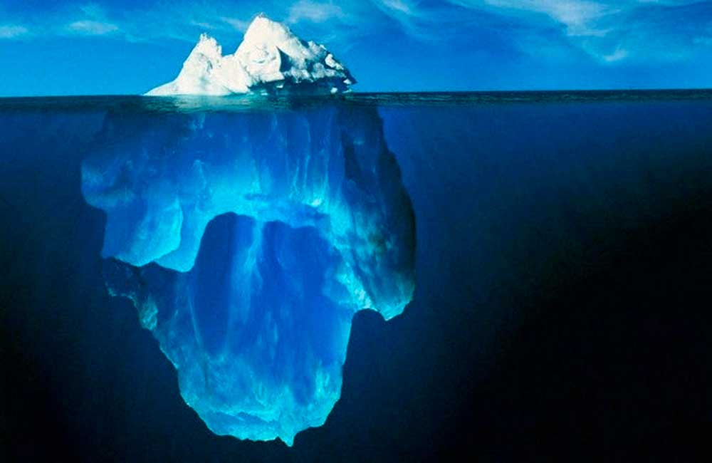

[figure not shown]

[figure not shown]

## Homework

- Eleven assignments, one in every session except this one and the last.
- Each opens when its session ends and is due seven days later.
- The schedule links a template repo. Create yours in the **`qmir-2026-fall`** organisation, named exactly `hw-NN-<username>`.

**Important**

**A sample solution is published for every homework. Individual feedback is NOT provided by default.** The only individual feedback available is the **optional AI feedback** you can opt into by adding an open-source `license.md` to your submission repo.

## The exam

- A take-home analysis, opening as the last session ends and running for two weeks.
- A dataset, a research question, and the eight steps you just watched.
- You submit a repository that someone else can render, plus a PDF.

**Note**

**You have now seen the entire shape of it.** Nothing on the exam is a step this course did not spend a week on.

# Recap: the normal distribution

## The normal distribution

Equation 1 said that every answer is normally distributed. That distribution has two knobs, and nothing else.

- $\mu$ is the mean, and moving it slides the whole curve left or right.
- $\sigma$ is the standard deviation, and raising it makes the curve wider and flatter.

**View source**

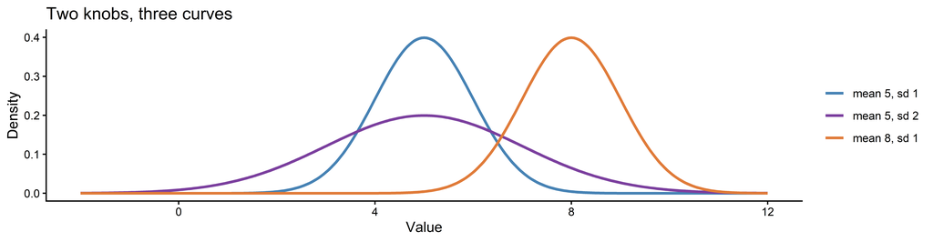

Figure 9: Three normal distributions. Changing the mean slides the curve sideways, changing the standard deviation changes how wide it is, and no other shape is available.

```r
normal_curves <- bind_rows(
  tibble(
    curve = "mean 5, sd 1",
    x = seq(-2, 12, by = 0.05),
    density = dnorm(x, 5, 1)
  ),
  tibble(
    curve = "mean 5, sd 2",
    x = seq(-2, 12, by = 0.05),
    density = dnorm(x, 5, 2)
  ),
  tibble(
    curve = "mean 8, sd 1",
    x = seq(-2, 12, by = 0.05),
    density = dnorm(x, 8, 1)
  )
)

ggplot(normal_curves, aes(x = x, y = density, colour = curve)) +
  geom_line(linewidth = 1) +
  scale_colour_manual(values = c(col_1, col_3, col_2)) +
  theme_classic() +
  labs(
    x = "Value",
    y = "Density",
    colour = NULL,
    title = "Two knobs, three curves"
  )
```

## The 68 and 95 rule

The area under the curve is probability, and for a normal distribution that area always splits the same way, whatever $\mu$ and $\sigma$ happen to be.

**View source**

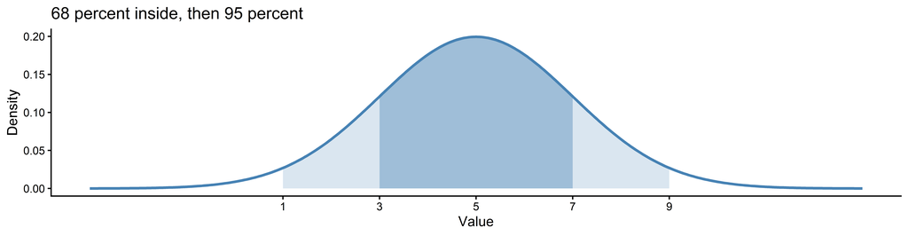

Figure 10: A normal distribution with mean 5 and standard deviation 2. About 68 percent of the area lies within one standard deviation of the mean, and about 95 percent within two, which is where the reading of the prior on the intercept came from.

```r
normal_area <- tibble(x = seq(-3, 13, by = 0.05), density = dnorm(x, 5, 2))

ggplot(normal_area, aes(x = x, y = density)) +
  geom_area(
    data = filter(normal_area, x >= 1, x <= 9),
    fill = col_1,
    alpha = 0.2
  ) +
  geom_area(
    data = filter(normal_area, x >= 3, x <= 7),
    fill = col_1,
    alpha = 0.4
  ) +
  geom_line(colour = col_1, linewidth = 1) +
  scale_x_continuous(breaks = c(1, 3, 5, 7, 9)) +
  theme_classic() +
  labs(x = "Value", y = "Density", title = "68 percent inside, then 95 percent")
```

This is exactly why $\alpha \sim \mathcal{N}(5, 2)$ was read as 5 plus or minus about 4.

## The standard normal

$\mathcal{N}(0, 1)$, a mean of 0 and a standard deviation of 1, is the reference curve. Every other normal distribution is that same shape, shifted and stretched.

$$z_i = \frac{x_i - \mu}{\sigma}
\tag{5}$$

**View source**

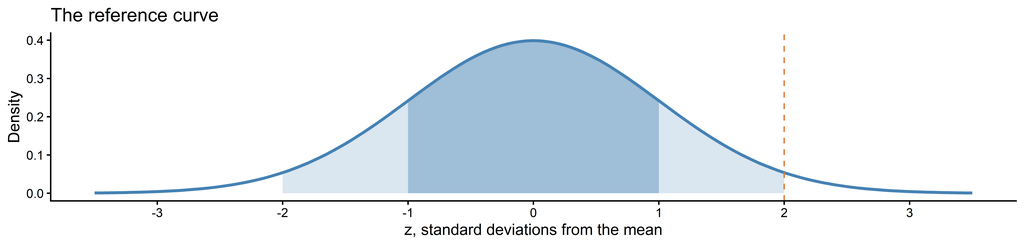

Figure 11: The standard normal, mean 0 and standard deviation 1, shaded the same way as Figure 10. The axis is no longer scale points but standard deviations, and the dashed line marks z equal to 2, the edge of the 95 percent region.

```r
standard_normal <- tibble(z = seq(-3.5, 3.5, by = 0.05), density = dnorm(z))

ggplot(standard_normal, aes(x = z, y = density)) +
  geom_area(
    data = filter(standard_normal, z >= -2, z <= 2),
    fill = col_1,
    alpha = 0.2
  ) +
  geom_area(
    data = filter(standard_normal, z >= -1, z <= 1),
    fill = col_1,
    alpha = 0.4
  ) +
  geom_line(colour = col_1, linewidth = 1) +
  geom_vline(xintercept = 2, linetype = "dashed", colour = col_2) +
  scale_x_continuous(breaks = -3:3) +
  theme_classic() +
  labs(
    x = "z, standard deviations from the mean",
    y = "Density",
    title = "The reference curve"
  )
```

Subtracting the mean and dividing by the standard deviation turns any normal variable into a standard normal one, which is the curve in Figure 11. A value of $z_i = 2$ then means the same thing everywhere: two standard deviations above the mean, which Figure 10 puts at the edge of the 95 percent region.

## Next week

- Install everything from the **Installation** page before the session.
- Send me your GitHub username.
- Week 2: Quarto, Git, and your first reproducible document.